# Recommender Systems - Mini-Challenge 2

Ricchard Nef, Mojzis Masár

4/27/2022

## 1. Teil

### 1.1 Einlesen von MovieLense

Es werden die nötigsten Libraries eingelesen

Der Datensatz wird in seine Bestandteile aufgeteilt. Bei `ratings` haben wir pro User und Film eine einzige Beweertung. Unter `users` haben wir zusätzliche Informationen zu jedem User, wie sein Alter, Beruf, Geschlecht und Wohnort. In unserer Analyse sind diese Daten nicht weiter relevant. Beim Datensatz `movies` interesieren uns die Genres, welche in der weiteren Analyse von grossem Wert sein werden.

### 1.2 Binäre User-Liked-Items Matrix für alle Nutzer erzeugen.

```r
# binary liked-items matrix
bin_rating_matrix <- ratings %>%
    mutate(rating = ifelse(ratings$rating > 3, 1, 0)) %>%
        pivot_wider(id_cols = "user",names_from = "item", values_from = "rating")
# set index
row.names(bin_rating_matrix) <- bin_rating_matrix$user
# drop user column
bin_rating_matrix[1] <- NULL
```

Im gesamten MovieLense Datensatz haben wir 943 Personen und 1664 Filme. In diesem Script haben wir uns entschieden, dass Filme mit ener Bewertung über 3 als gut Bewertet werden (1) und die anderen nicht (0). Das brauchen wir um zu wissen, welche Filme dem Nutzer gefallen und nicht. Wenn man diesen Wert zu weit runter setzt, kann es sein, dass man zu viele Empfehlungen bekommet und so die minimale Ähnlichkeit abnimmt. Um diesen Defizit zu umgehen, muss man ein Gleichgewicht finden zwischen Über- und Unterbeweertung der Ratings.

### 1.3.Dimension der User-Liked-Items Matrix prüfen und ausgeben.

```r
# dimensions of the liked-items matrix
dim(bin_rating_matrix)
```

```
## [1]  943 1664
```

Wir überprüfen nun ob die neue binäre Tabelle weiterhin das richtigen Ausmass behält und keine Filme oder User verloren gegangen sind. Da wir sehen, dass die Matrix immeer noch 943 x 1664 ist, können wir unbesorgt weiterfahren.

### 1.4.Movie-Genre Matrix für alle Filme erzeugen.

```r
# movie-genre matrix
movies_genre <- movies
rownames(movies_genre) <- movies_genre$title
movies_genre <- movies_genre %>%
  select(-c(year, url, title))

movies_genre <- as.matrix(movies_genre)
```

Wir nehemn in diesem Schritt die `movies` Tabelle und werfen alle Variablen raus, welche uns nicht mehr von Nutzen sind. Das ist das Erscheinungsjahr und die [Webseite der Bewertungen und Informationen][http://us.imdb.com]. des jeweiligen Filmes. Zusätzlich haben wir den Namen der Filme als Zeilennamen konfiguriert.

### 1.5.Dimension der Movie-Genre Matrix prüfen und ausgeben.

```r
# dimensions of the movie-genre matrix
dim(movies_genre)
```

```
## [1] 1664   19
```

Diese neue Matrix hat eine Dimension von 1664 x 19. Diese Zahlen zeigen uns, dass wir in dieser Tabelle alle 1664 Filme mit 19 verfügbaren Genres haben.

### 1.6 Anzahl unterschiedlicher Filmprofile bestimmen und visualisieren.

```r
gen_pro <- as.data.frame(movies_genre)
gen_pro <- map2_df(gen_pro, colnames(gen_pro), ~  c(NA, .y)[.x +1])
#set names instead of value 1

gen_pro <- gen_pro %>%
  group_by_all() %>% #group all possible film-profiles
  summarize(count = n()) %>%
  arrange(desc(count)) %>%
  ungroup()
```

[output not shown]

```r
namen = names(gen_pro)[-20]

film_profil <- gen_pro %>%
  mutate_at(vars(namen), as.character) %>%
  unite(Profile, namen, sep="-",na.rm=TRUE) %>% #set variable with combined names
  mutate(Profile=ifelse(Profile %in% head(Profile, 30),
                        Profile, "Others combined" )) %>%
  mutate(Profile=factor(Profile, levels=unique(Profile))) %>%
  group_by(Profile) %>%
  summarize(count=sum(count))
```

```
## Note: Using an external vector in selections is ambiguous.
## ℹ Use `all_of(namen)` instead of `namen` to silence this message.
## ℹ See <https://tidyselect.r-lib.org/reference/faq-external-vector.html>.
```

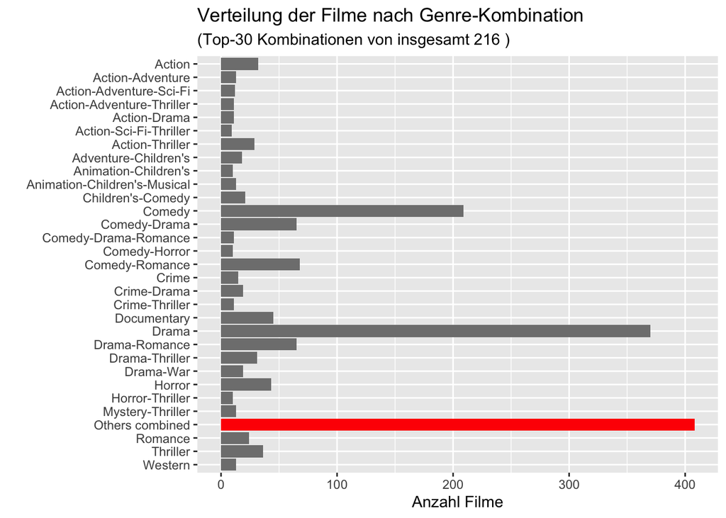

```r
film_profil$Profile <- as.character(film_profil$Profile)

film_profil <- film_profil %>% arrange(Profile)

ggplot(film_profil)+
  geom_col(aes(x=film_profil$count,
               y=film_profil$Profile,
               fill=factor(ifelse(Profile=="Others combined",
                                  "Others combined", "Profile"))),
           show.legend = FALSE)+
  scale_fill_manual(name="Profile", values = c("red", "grey50"))+
  scale_y_discrete(limits=rev)+
  labs(x="Anzahl Filme",
       y="",
       title = "Verteilung der Filme nach Genre-Kombination",
       subtitle = paste("(Top-30 Kombinationen von insgesamt", dim(gen_pro)[1],
       ")"))
```

Man kann sehen, dass das am meisten vorkommente Genre-Profil Drama ist mit 370 Vorkommnissen, gefolgt von Comedy mit 209. Die restliche 186 Genre-Profile, welche nicht mehr auf dieser Visualisierung vorzufinden sind, kommen insgesamt 408 mal vor.

### 1.7.User-Genre-Profil Matrix mit Nutzerprofilen im Genre-Vektorraum erzeugen.

```r
# user-genre-profile matrix
bin_rating_matrix_1_7 <- as.matrix(bin_rating_matrix) %>%
  replace(is.na(.), 0)

user_genre <-  bin_rating_matrix_1_7 %*% movies_genre

head(user_genre, 3)
```

```
##      unknown Action Adventure Animation Children's Comedy Crime Documentary
## [1,]       1     39        17         5          5     49    15           5
## [2,]       0      7         3         1          2     12     6           0
## [3,]       0      3         2         0          0      3     3           1
##      Drama Fantasy Film-Noir Horror Musical Mystery Romance Sci-Fi Thriller War
## [1,]    77       1         1      7       6       3      29     32       30  15
## [2,]    22       0         2      0       0       1      13      2        6   2
## [3,]     7       0         0      0       0       4       2      2        4   2
##      Western
## [1,]       3
## [2,]       0
## [3,]       0
```

In dieser Matrix sieht man wie viele Genres jede Person gesehen hat. Mit dieser Matrix haben wir ein Profil von jeder Person und können so sehen, wer wem ähnlich ist und dementsprechend Filme empfehlen. Bei diesen drei Personen sieht man, dass sie recht unterschiedlich sind. Wärend wir von der ersten Person ein recht eindeutiges Profil haben ( Sie hat eine Vorliebe für Drama, Comedy und Action, geniesst aber gerne einen Romantischen Abend mit ihrem Partner), können wir von der dritten Person nur sagen, dass sie eine Tendenz für Drama, Mystery und Thriller hat. Im Verhältnis zu der Menge der Filme die sie geschaut hat, können wir aber noch kein klares Profil erkennen.

### 1.8.Dimension der User-Genre-Profil Matrix prüfen und ausgeben.

```r
# dimensions of the user-genre-profile matrix
dim(user_genre)
```

```
## [1] 943  19
```

Hier sehen wir nochmals, dass diese Matrix alle 943 Kunden beinhaltet sowie alle 19 Genres.

```r
# vollständig
rating_matrix <- ratings %>%
        pivot_wider(id_cols = "user",names_from = "item", values_from = "rating")
# set index
row.names(rating_matrix) <- rating_matrix$user
# drop user column
rating_matrix[1] <- NULL
```

```r
# vollständig
n_profile_v <- rating_matrix
```

```r
# nur binär
n_profile_b <- bin_rating_matrix %>%
mutate(across(.cols = everything(), .fns = ~
  ifelse(.x > 3, 1, 0)))
```

## 2.Ähnlichkeit von Nutzern und Filmen

### 2.1.Cosinus-Ähnlichkeit zwischen User-Genre- und Movie-Genre-Matrix berechnen.

Funktion zur Berechnung von Cosinus-Ähnlichkeiten zweier Matrizen namens calc_cos_similarity_twomtrx() implementieren, um Nutzerprofile und Filme im Vektorraum der Genres zu vergleichen. Die richtige Funktionsweise soll an einem einfachen Beispiel getestet und dokumentiert werden.

```r
calc_cos_similarity_twomtrx <- function (user_genre, movies_genre) {
  # check dimensions
  if (dim(user_genre)[2] != dim(movies_genre)[2]) {
    stop("Dimensions of user_genre and movies_genre do not match")
  }

  #calculate cosine similarity between user-genre-profile matrix and movie-genre-profile matrix
  ug_2 <- user_genre*user_genre
  mg_2 <- movies_genre*movies_genre
  user_genre_norm <- user_genre / sqrt(rowSums(ug_2))
  movies_genre_norm <- movies_genre / sqrt(rowSums(mg_2))

  # calculate t crossproduct
  t <- tcrossprod(user_genre_norm, movies_genre_norm)
  return(t)
}
```

```r
(A <- matrix(c(1, 2, 0, 4), nrow = 2, ncol = 2, byrow = TRUE))
```

```
##      [,1] [,2]
## [1,]    1    2
## [2,]    0    4
```

```r
(B <- matrix(c(1, 0, 0, 1), nrow = 2, ncol = 2, byrow = TRUE))
```

```
##      [,1] [,2]
## [1,]    1    0
## [2,]    0    1
```

```r
calc_cos_similarity_twomtrx(A, B)
```

```
##           [,1]      [,2]
## [1,] 0.4472136 0.8944272
## [2,] 0.0000000 1.0000000
```

Anhand dieses einfaches Beispieles können wir überprüfen, dass die Formel der Cosinus-Similarity richtig berechnet wird. Wir werden die Formel dazu benutzen, die Cosinus-Similarity für alle Filme von allen User zu berechnen um in einem späteren Zeitpunk die besten herauszufiltern und somit gute Empfehlungen machen zu können.

```r
# cosinus similarity between user-genre- and movie-genre-matrices
cos_2_1 <- calc_cos_similarity_twomtrx(user_genre, movies_genre)
```

### 2.2. Dimension der Matrix der Cosinus-Ähnlichkeiten von Nutzern und Filmen prüfen uns ausgeben.

```r
dim(cos_2_1)
```

```
## [1]  943 1664
```

Wir sehen anhand der Grösse der resultierenden Matzrix, dass wir für jede der 943 Personen Werte über alle 1664 Filme haben

### 2.3. 5-Zahlen Statistik für Matrix der Cosinus-Ähnlichkeiten prüfen und

ausgeben.

```r
q_cos <- quantile(cos_2_1,probs = c(0.25,0.5,0.75), na.rm = TRUE)
```

### 2.4.Cosinus-Ähnlichkeiten von Nutzern und Filmen mit Dichteplot visualisieren.

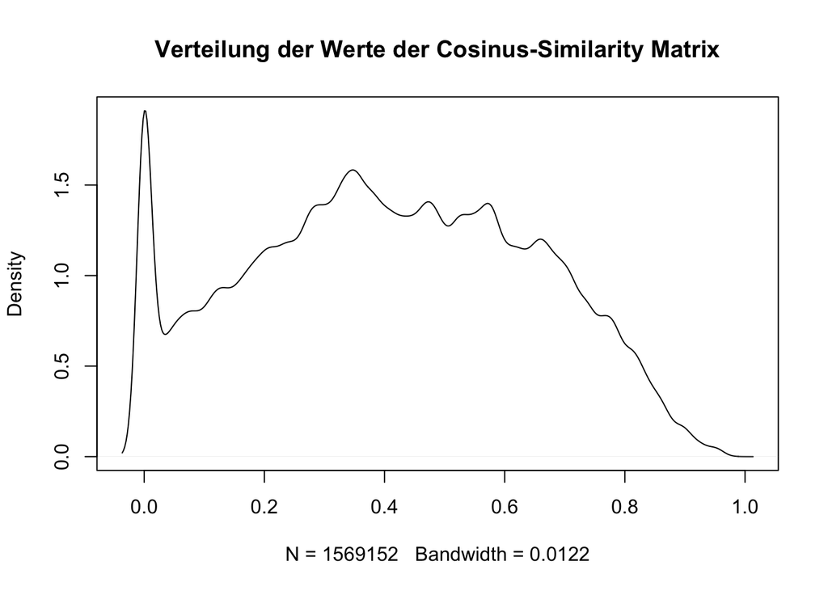

```r
# Kernel Density Plot
cos_2_1_Nona <- cos_2_1 %>%
        replace(is.na(.), 0)

plot(density(cos_2_1_Nona), main="Verteilung der Werte der Cosinus-Similarity Matrix")
```

```r
p0 <- round((sum(cos_2_1_Nona==0)/length(cos_2_1_Nona))*100, 2)
```

Bei der Grafik der Verteilung der Werte der Cosinus-Similarity Matrix ist zu beobachten, dass es eine Spitze gibt für die Bewertung 0. Dies kann davon kommen, dass viele Personen nur wenige Filme angeschaut haben. Daher werden für Filme welche ein völlig anderes Genre haben, eine Empfehlung von 0 oder sehr gering abgiebt. Insgesamt haben 5.44% der Filme ein vorausgesagte Bewertung von 0.

### 2.5.Cosinus-Ähnlichkeiten von Nutzern und Filmen mit Dichteplot für Nutzer

“241”, “414”, “477”, “526”, “640” und “710” visualisieren.

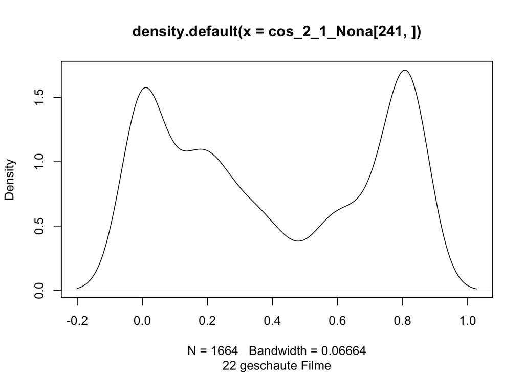

```r
c241 <- 1664-rowSums(is.na(rating_matrix[241,]))
c414 <- 1664-rowSums(is.na(rating_matrix[414,]))
c477 <- 1664-rowSums(is.na(rating_matrix[477,]))
c526 <- 1664-rowSums(is.na(rating_matrix[526,]))
c640 <- 1664-rowSums(is.na(rating_matrix[640,]))
c710 <- 1664-rowSums(is.na(rating_matrix[710,]))

plot(density(cos_2_1_Nona[241,]), sub = paste(c241, "geschaute Filme"))
```

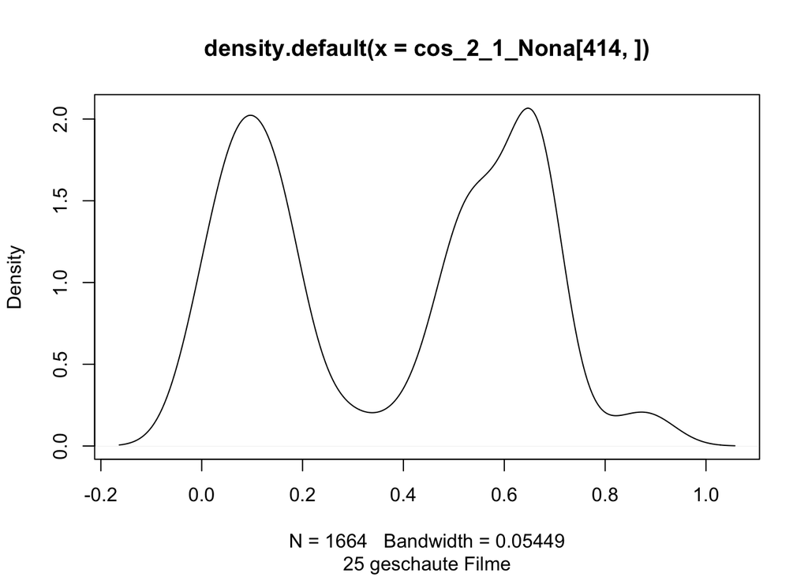

```r
plot(density(cos_2_1_Nona[414,]), sub = paste(c414, "geschaute Filme"))
```

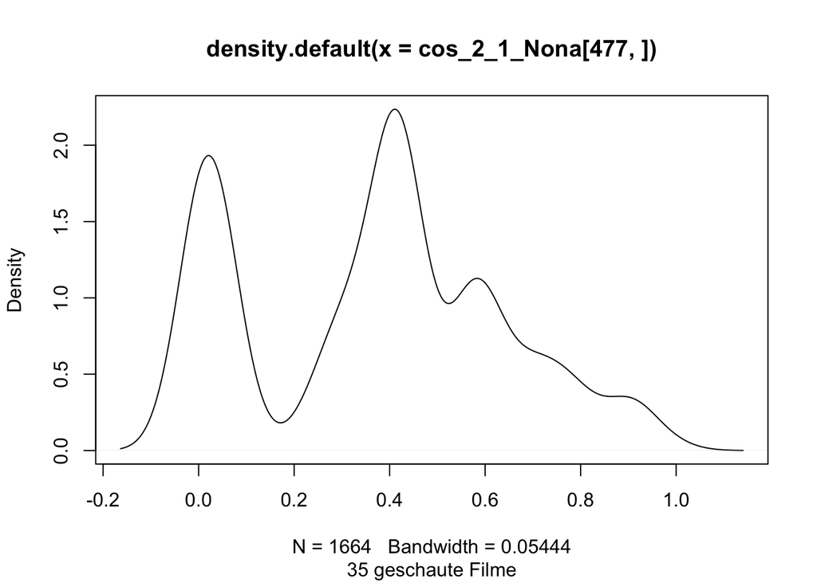

```r
plot(density(cos_2_1_Nona[477,]), sub = paste(c477, "geschaute Filme"))
```

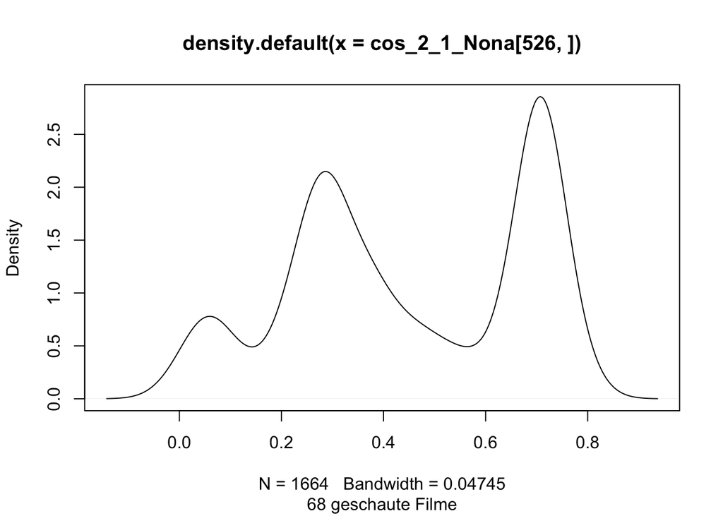

```r
plot(density(cos_2_1_Nona[526,]), sub = paste(c526, "geschaute Filme"))
```

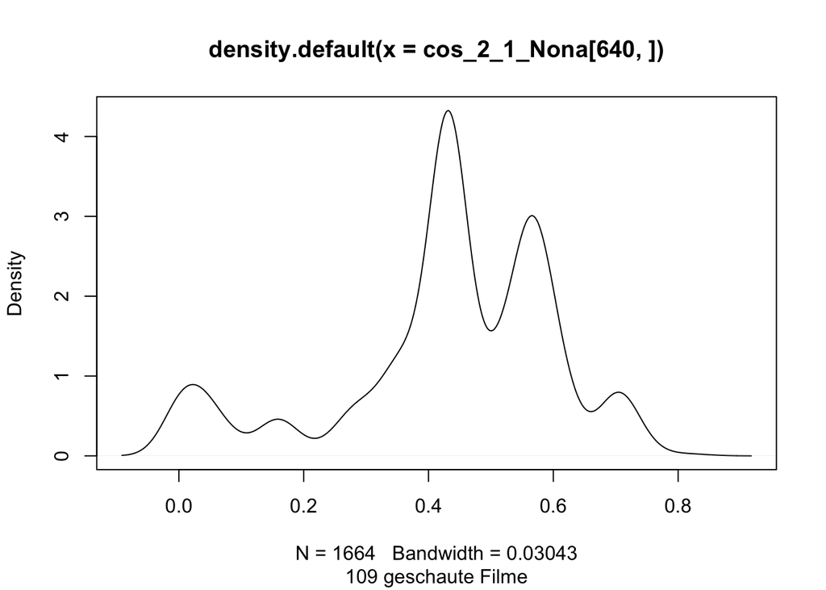

```r
plot(density(cos_2_1_Nona[640,]), sub = paste(c640, "geschaute Filme"))
```

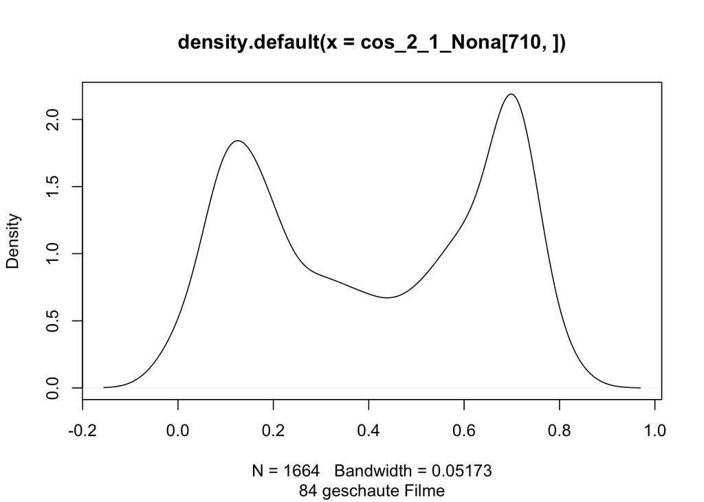

```r
plot(density(cos_2_1_Nona[710,]), sub = paste(c710, "geschaute Filme"))
```

Anhand dieser Plots sieht man die Verteilung der vorergesagten Bewertungen sehen. In den Bewertungen an sich gibt es keinen Zusammenhang zwischen der Anzahl gesehener Filme und den Bewertungen. Man sieht jedoch ob ein Nutzer vorwiegend gute oder schlechte Bewertungen abgibt.

# 3. Empfehlbare Filme

### 3.1 Bewertete Filme maskieren, d.h. “Negativabzug” der User-Items

Matrixerzeugen, um anschliessend Empfehlungen herzuleiten.

```r
#negativabzug for recommendations
bin_rating_matrix_nabz <- bin_rating_matrix %>%
        replace(!is.na(.), FALSE) %>%
        replace(is.na(.), TRUE)

#Positivabzug for further analysis
bin_rating_matrix_pos <- bin_rating_matrix %>%
        replace(!is.na(.), TRUE) %>%
        replace(is.na(.), FALSE)
```

### 3.2 Zeilensumme des “Negativabzuges” der User-Items Matrix für die User

“5”,“25”, “50” und “150” ausgeben.

```r
# calculate sum of not rated movies from costumer 5,25,50,150
bin_rating_matrix_nabz_sums <- bin_rating_matrix_nabz %>%
  slice(c(5,25,50,150)) %>%
  rowSums()

bin_rating_matrix_nabz_sums
```

```
## [1] 1489 1586 1641 1633
```

Diese Zahlen zeigen uns, dass diese Personen entsprechende Anzahl Filme *nicht* gesehen haben. Die Person 5 hat 1489 Filme nicht gesehen, Person 25 hat 1586 nicht gesehen etc..

### 3.3 5-Zahlen Statistik der Zeilensumme des “Negativabzuges” der User-Items Matrix bestimmen.

```r
# 5 number statistic of bin_rating_matrix_nabz_sums_all
bin_rating_matrix_nabz_sums_all <- bin_rating_matrix_nabz %>% rowSums()
min_3_3 <- min(bin_rating_matrix_nabz_sums_all)
cat(" Min         = ",min_3_3,"\n")
```

```
##  Min         =  929
```

```r
q_3_3 <- quantile(bin_rating_matrix_nabz_sums_all,probs = c(0.25,0.5,0.75))
cat(" 25% quartil = ",q_3_3[1],"\n","Median      = ",q_3_3[2],"\n", "75% quartil = ",q_3_3[3],"\n")
```

```
##  25% quartil =  1516.5
##  Median      =  1600
##  75% quartil =  1632
```

```r
max_3_3 <- max(bin_rating_matrix_nabz_sums_all)
cat(" Max         = ",max_3_3,"\n")
```

```
##  Max         =  1645
```

Diese Statistik zeigt, dass man der Person mit den meisten gesehenen Filmen immer noch 929 Filme empfeheln könnte. Der Median liegt bei 1600 was bedeutet, dass die Hälfte der Personen 64 oder weniger Filme gesehen haben. Die Person mit den wenigsten gesehenen Filmen hat lediglich 19 Filme gesehen.

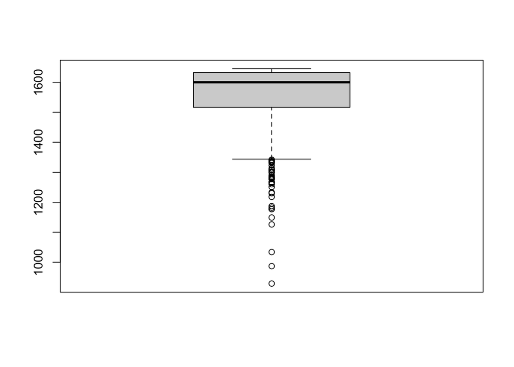

```r
boxplot(bin_rating_matrix_nabz_sums_all)
```

Der Boxplot zeigt nochmals, dass die hälfte der Personen zwischen 148 und 32 Filme gesehen hat.

# 4. Top-N Empfehlungen

### 4.1.Matrix für Bewertung aller Filme durch element-weise Multiplikation der

Matrix der Cosinus-Ähnlichkeiten von Nutzern und Filmen und “Negativabzug” der User-Items Matrix erzeugen.

```r
cos_mol_nabz  <-  cos_2_1 * as.matrix(bin_rating_matrix_nabz)
cos_mol_pos   <-  cos_2_1 * as.matrix(bin_rating_matrix_pos)
#cos_mol_pos für spätere Analyse der Empfehlungen
```

Diese Matrizen zeigen uns die Vorhergesagte Bewertung für die Filme die noch nicht geschaut worden sind. Filme die die jeweilige Person bereits gesehen hat, wurden mit einer `0` codiert. Auf diese Matrix basiert die Auswahl der Empfehlungen.

### 4.2.Dimension der Matrix für die Bewertung aller Filme prüfen.

```r
dim(cos_mol_nabz)
```

```
## [1]  943 1664
```

Die Dimension zeigt wieder, dass man für alle 943 Personen, 1664 Filme hat.

### 4.3.Top-20 Listen pro Nutzer extrahieren.

```r
topn <- 20
len <- dim(cos_mol_nabz)[1]

get_topn_recos <- function (m,u,n=topn){
  return(names(head(sort(m[u,],decreasing = TRUE),n)))
}

analyse_topn_recos <- function (m,n=topn,len=943){
  df <- data.frame(matrix(nrow = topn,ncol = len))
  for (user in 1:len){
    df[,user] <- get_topn_recos(m,user,n)
    }
  return (df)
}
top20_all <- analyse_topn_recos(cos_mol_nabz)
```

In der vorherigen Matrix haben wir alle Bewertungen für alle Filme evaluiert. Um die besten Filme für jede Person herauszufinden, müssen wir die Bewertungen von jeder einzelenen Person der Grösse nach ordnen.

```r
top20_all[1]
```

```
##                                                          X1
## 1                                  House of Yes, The (1997)
## 2                                           Best Men (1997)
## 3                                    Wings of Desire (1987)
## 4                                          Manhattan (1979)
## 5                            American President, The (1995)
## 6                                   Corrina, Corrina (1994)
## 7                            Something to Talk About (1995)
## 8                                   Don Juan DeMarco (1995)
## 9                                        Brassed Off (1996)
## 10                              What Happened Was... (1994)
## 11                                     Twelfth Night (1996)
## 12                               I Like It Like That (1994)
## 13                                As Good As It Gets (1997)
## 14                              Deconstructing Harry (1997)
## 15                                       Wag the Dog (1997)
## 16 Adventures of Priscilla, Queen of the Desert, The (1994)
## 17                                              Jack (1996)
## 18                                    Apartment, The (1960)
## 19                                       Down by Law (1986)
## 20                                    Cool Hand Luke (1967)
```

In dieser Tabelle sehen wir nun, dass z.B. der Person 1 entsprechende Filme empfohlen worden sind.

### 4.4.Länge der Top-20 Listen pro Nutzer prüfen.

```r
summary(sapply(top20_all, n_distinct))
```

```
##    Min. 1st Qu.  Median    Mean 3rd Qu.    Max.
##    1.00   20.00   20.00   19.98   20.00   20.00
```

```r
sum(is.na(top20_all)) #How many NA's are they?
```

```
## [1] 20
```

```r
apply(is.na(top20_all),1, which) #Reveal position of  NA's
```

```
##  [1] 685 685 685 685 685 685 685 685 685 685 685 685 685 685 685 685 685 685 685
## [20] 685
```

```r
top20_all$X685
```

```
##  [1] NA NA NA NA NA NA NA NA NA NA NA NA NA NA NA NA NA NA NA NA
```

### 4.5. Verteilung der minimalen Ähnlichkeit für Top-N Listen für N = 10, 20, 50 und 100 für alle Nutzer visuell vergleichen.

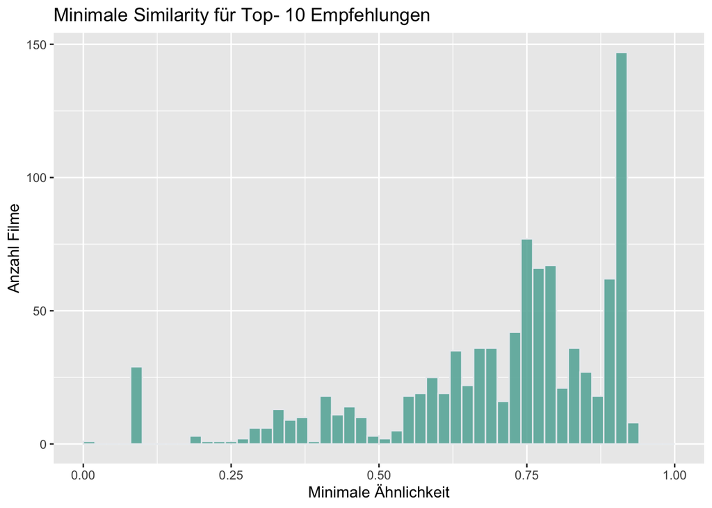

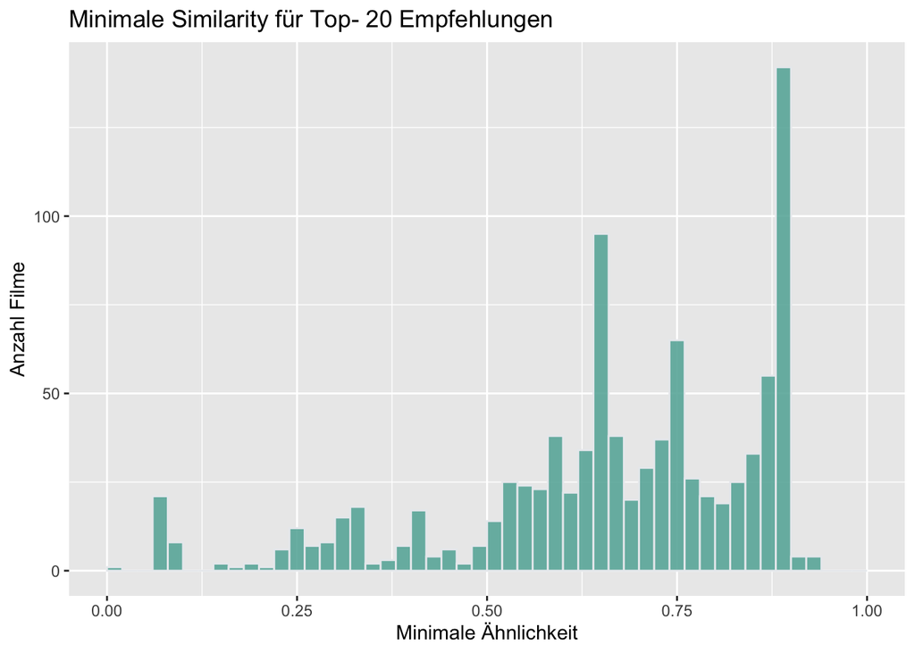

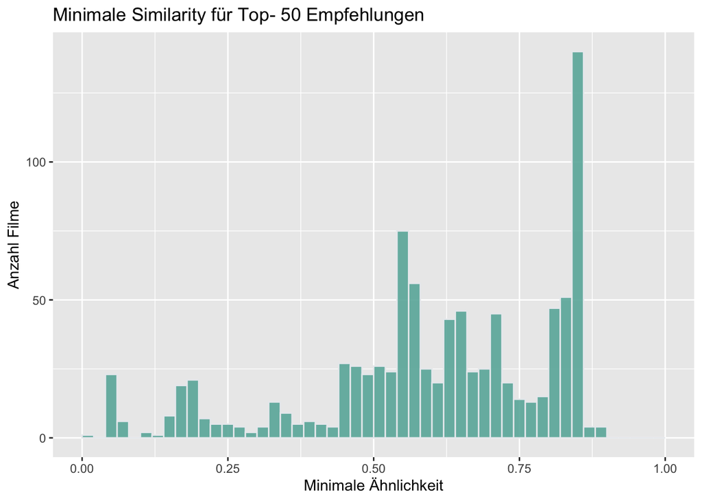

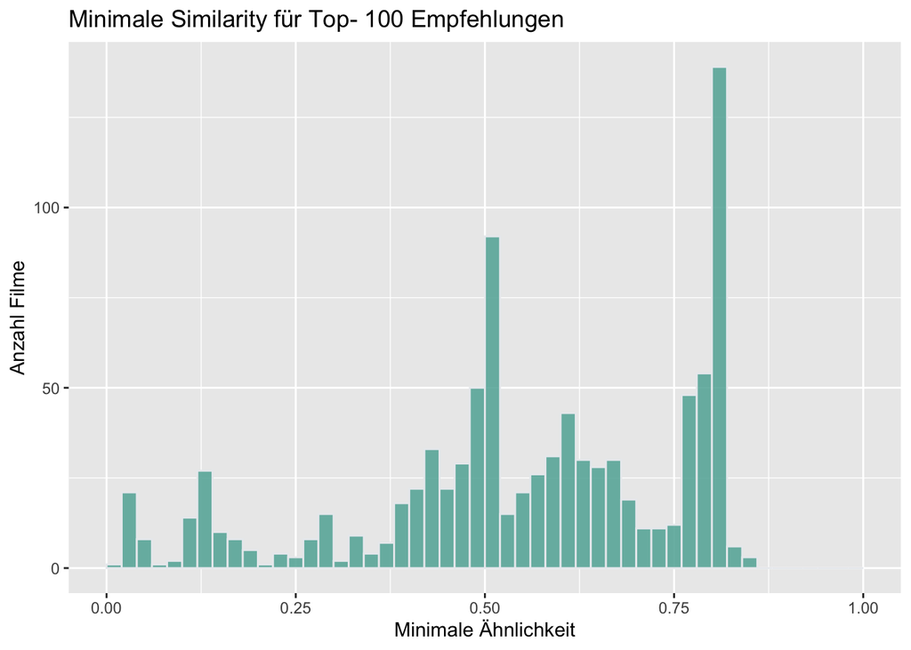

```r
topnlist <- c(10,20,50,100)

get_topn_recos_values <- function (m,u,n=top.n){
  return(head(sort(m[,u],decreasing = TRUE),n))
}

analyse_topn_recos_values <- function (m,n=top.n,len=943){
  df <- data.frame(matrix(nrow = top.n,ncol = len))
  for (user in 1:len){
    df[,user] <- get_topn_recos_values(m,user,n)
    }
  return (df)
}

for (i in 1:length(topnlist)){
  top.n <- topnlist[i]

  topN_all_values <- analyse_topn_recos_values(cos_mol_nabz)
  top_n_df <- stack(as.data.frame(topN_all_values))
  min_val <- as.numeric(tail(topN_all_values, 1))

  top_n_vis <- ggplot()+
    aes(min_val)+
    stat_bin(breaks=seq(0,1,0.02), fill="#69b3a8", color="#e9ecef", alpha=0.9)+
    labs(x = "Minimale Ähnlichkeit",
         y = "Anzahl Filme",
         title = paste("Minimale Similarity für Top-",top.n, "Empfehlungen"))

  print(top_n_vis)
}
```

### 4.6.Top-20 Empfehlungen für Nutzer “5”, “25”, “50” und “150” visuell evaluieren.

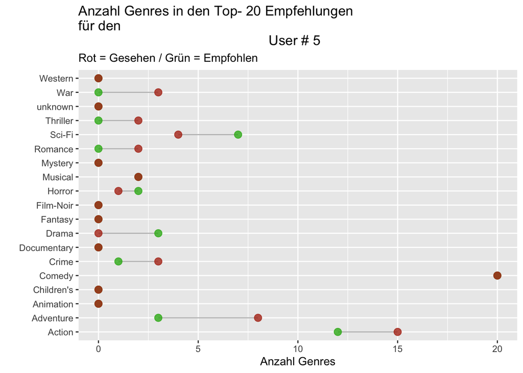

```r
prediction(5)
```

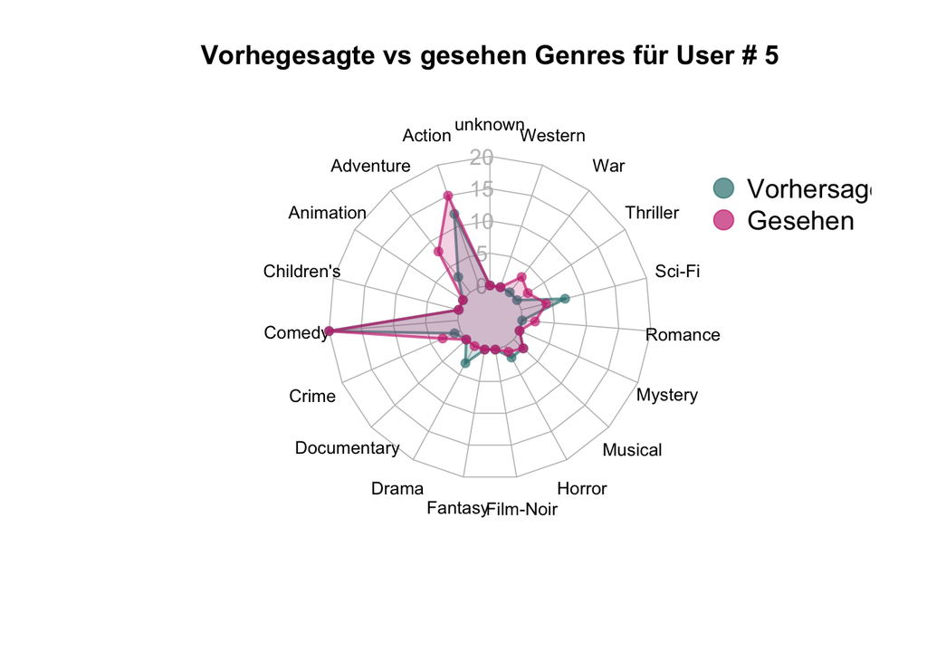

```r
prediction(5, plot = "spider")
```

```r
ggplotly(prediction(5))
```

[interactive chart not shown]

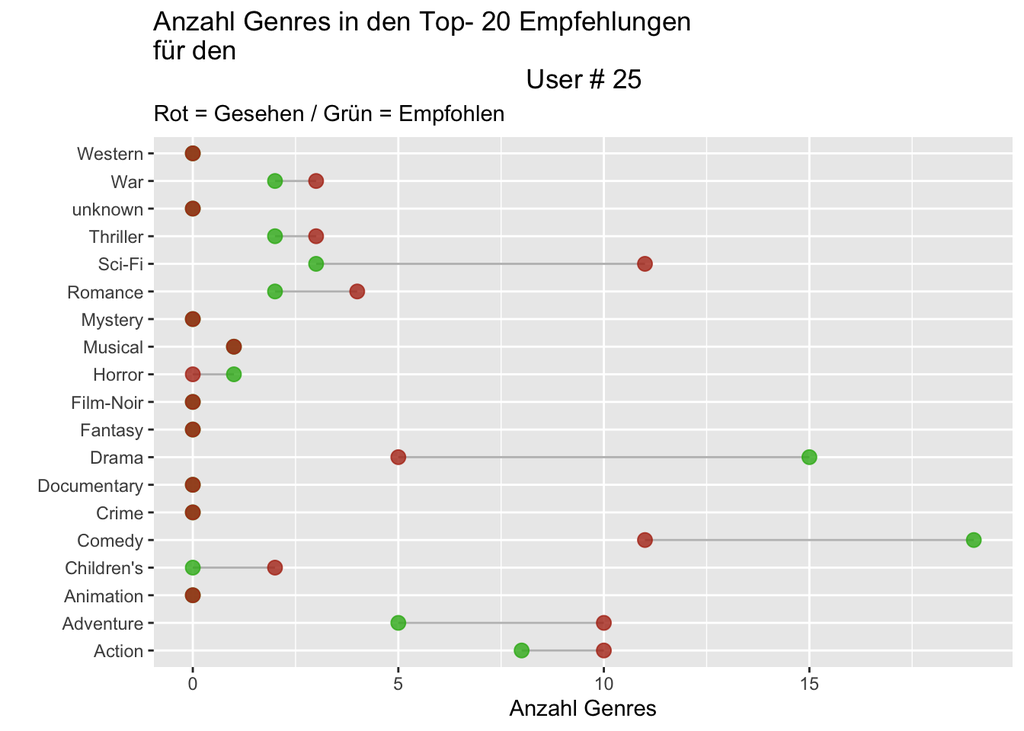

```r
prediction(25)
```

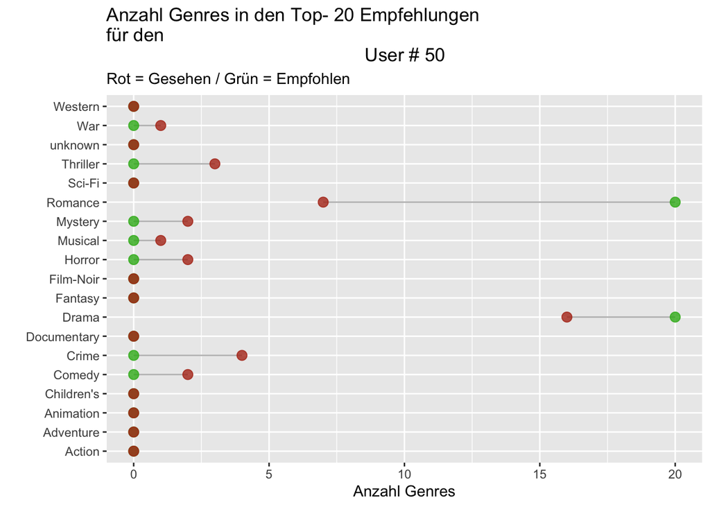

```r
prediction(50)
```

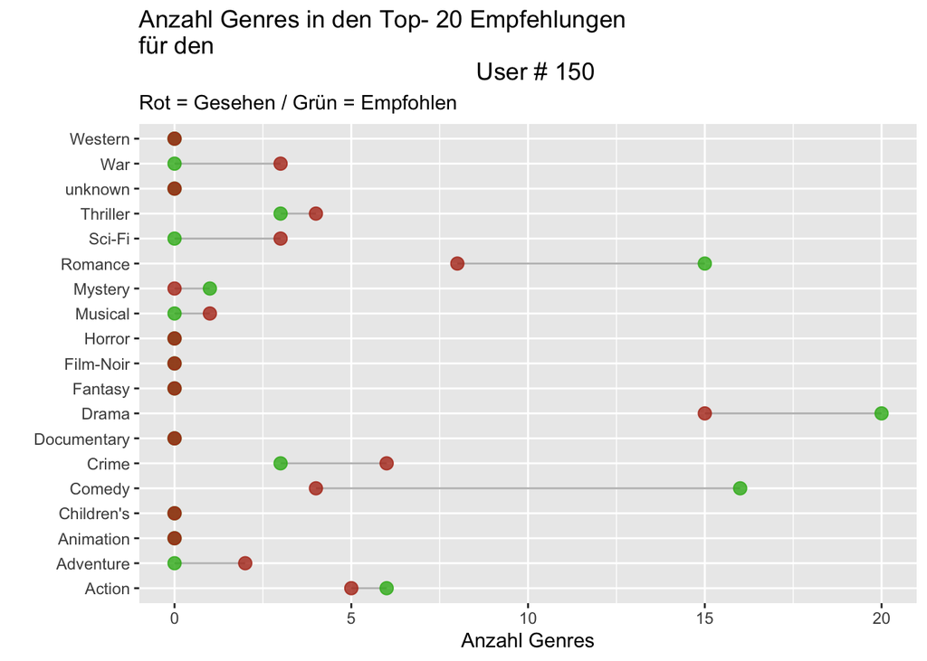

```r
prediction(150)
```

### 4.7.Für Nutzer “133” und “555” Profil mit Top-N Empfehlungen für

N = 20, 30, 40, 50 analysieren, visualisieren und diskutieren.

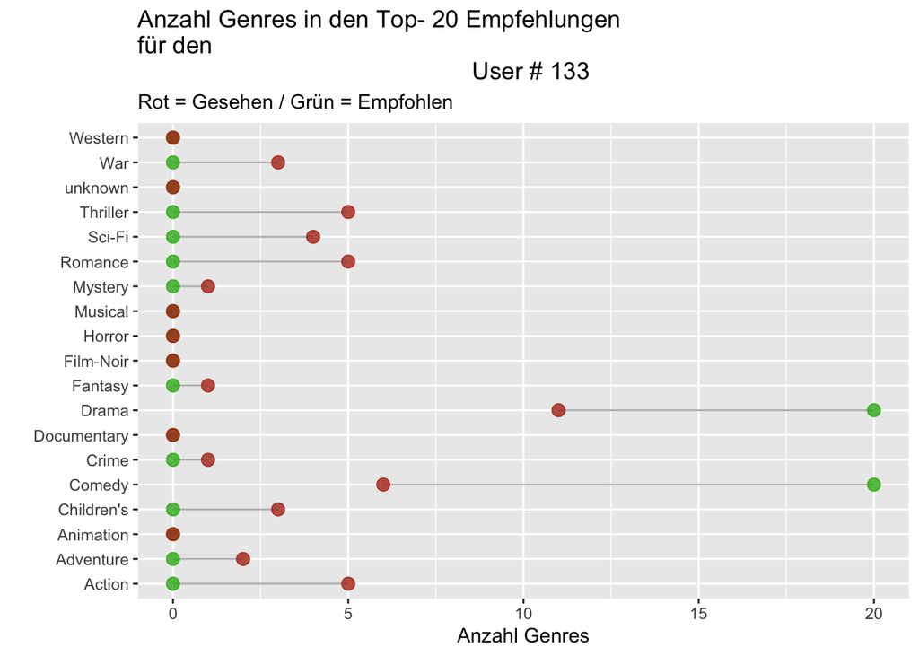

```r
prediction(133, 20)
```

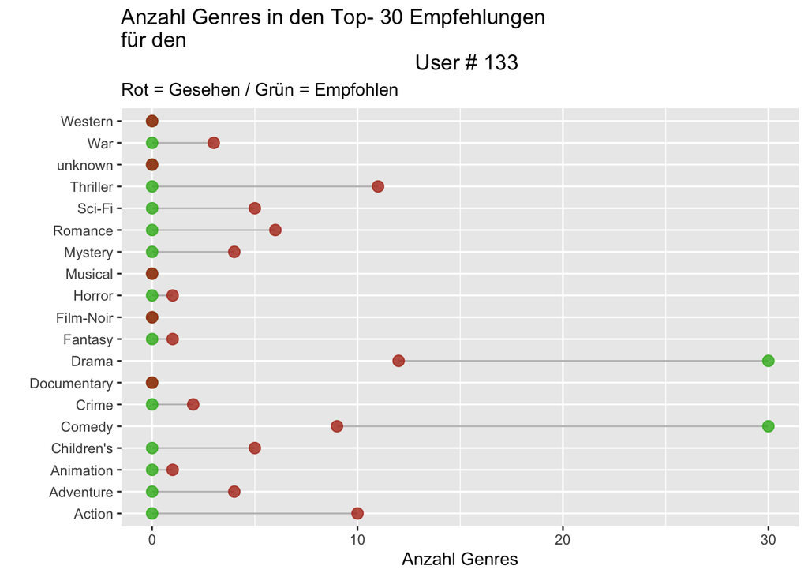

```r
prediction(133, 30)
```

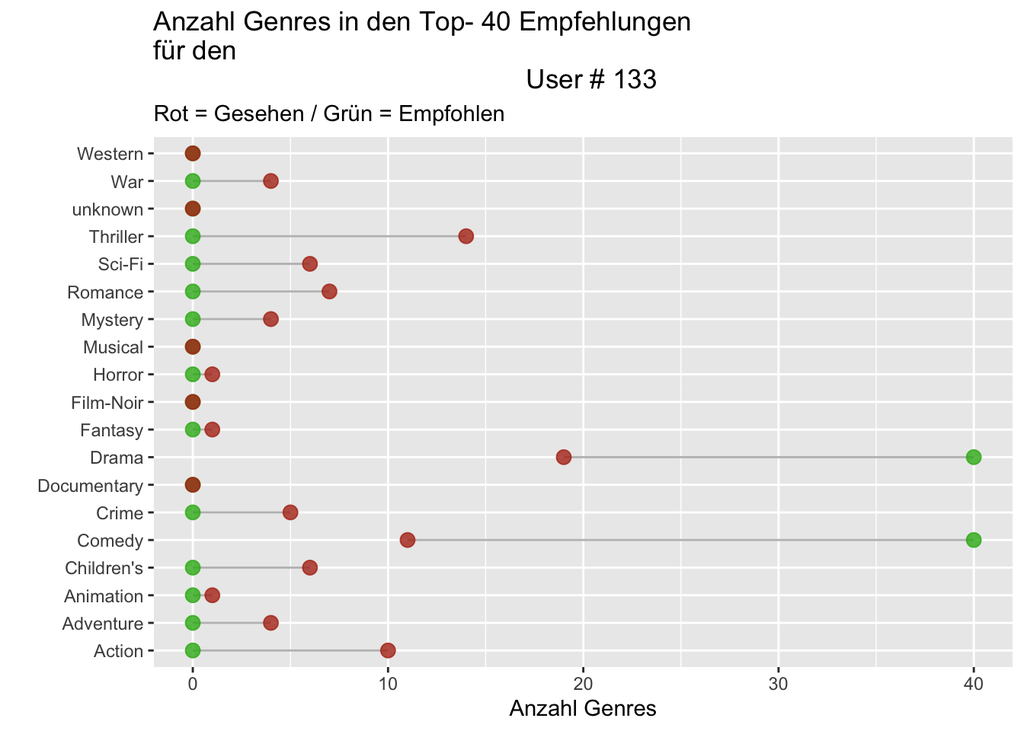

```r
prediction(133, 40)
```

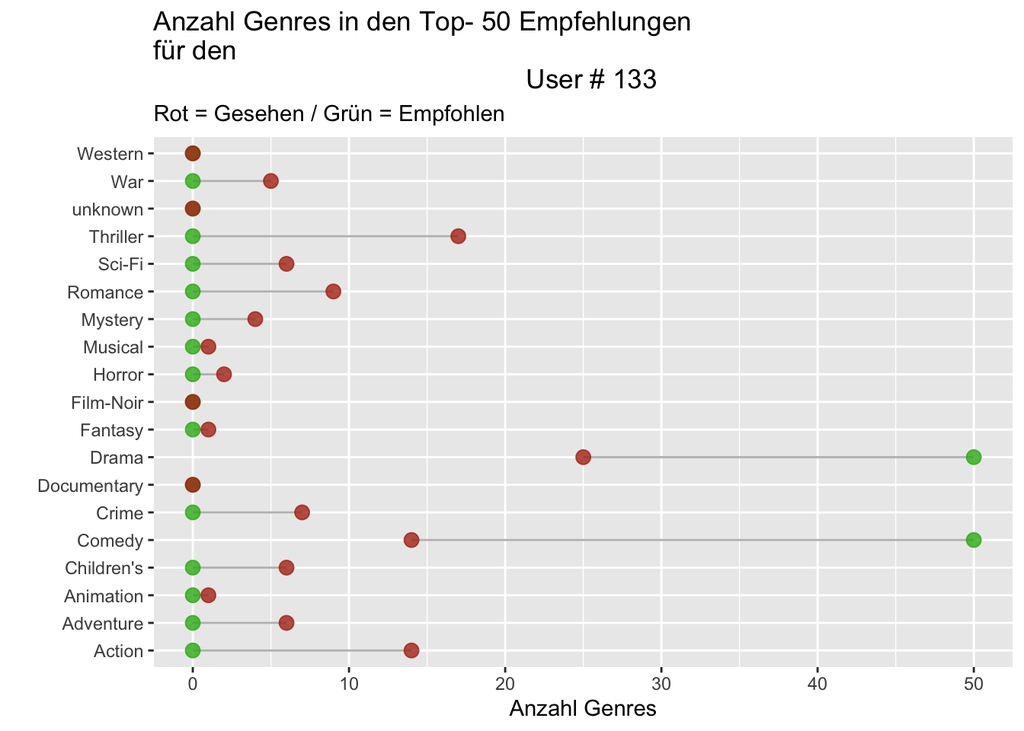

```r
prediction(133, 50)
```

Die Person 133 hat einen interesanten recommender. Es werden Ihr nur Drama und Comedy empfohlen. Das ist soweit verwunderlich, da sie Action und Thriller fast gleich oft gesehen hat wie Comedy, diese ihr aber nicht mehr empfohlen werden. Das kann vielleicht wegen den Filmprofile sein. Wir visualisieren hier die einzelnen Genres, haben aber gesehen, dass bei vielen Filmen 2 oder mehr Genres vorhanden sind. Dies könnte ein Grund für diese Erscheinung sein.

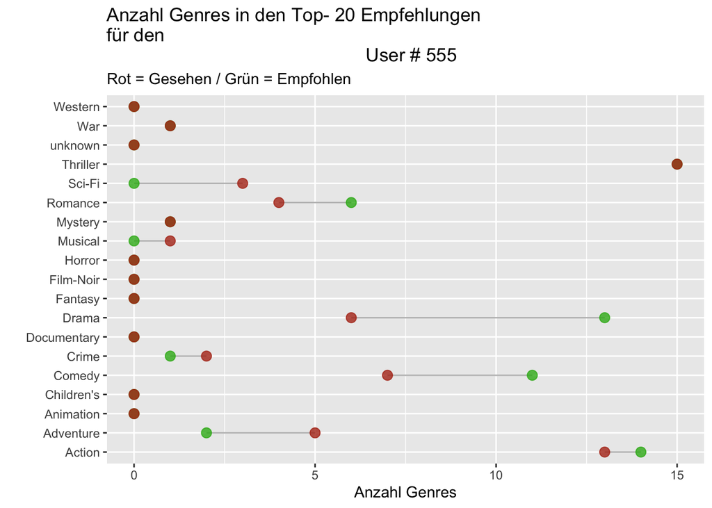

```r
prediction(555, 20)
```

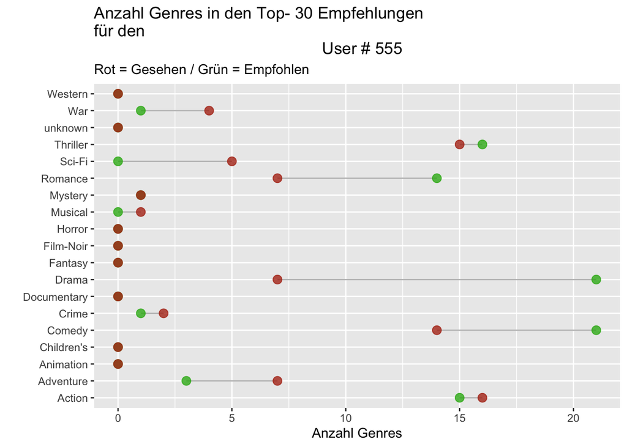

```r
prediction(555, 30)
```

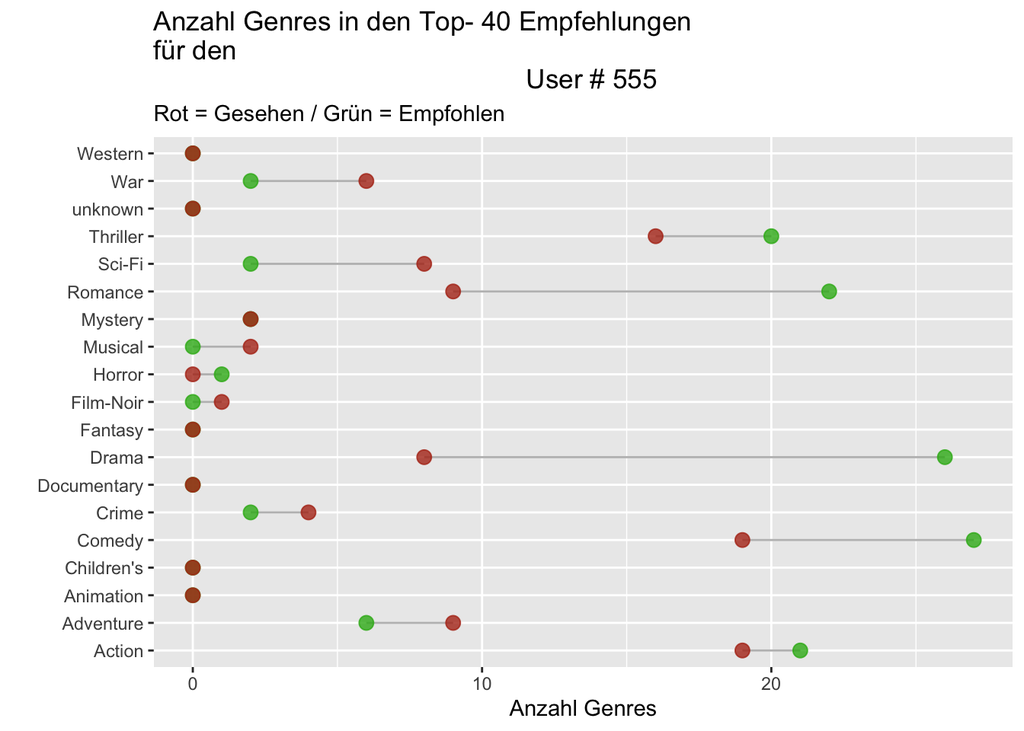

```r
prediction(555, 40)
```

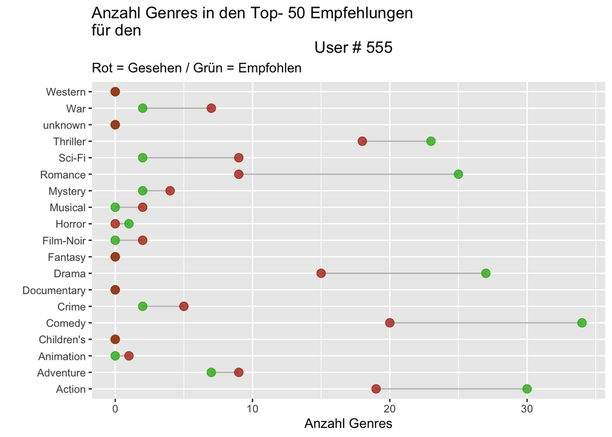

```r
prediction(555, 50)
```

Die Person 555 hat ein sehr breites Profil.Hervorzuheben ist, dass mit steigenden Top-N weniger Thriller und mehr Comedy empfohlen werden. Ausserdem schaut diese Person oder dieses Profil sehr viele unterschiedliche Genres. Das könnte damit zusammenhängen, dass es ein geteilter Account ist.